# Re-analysing ADVANCE with the Win Ratio

Severine Bompoint

2026-09-07

# WINS examples

## Example 1: a binary outcome

There is an example dataset called `data_binary` included in `WINS` for demonstration:

```r
library(WINS)


head(data_binary)
```

```
##   id arm Y_1 Y_2 Y_3
## 1  1   A   0   0   0
## 2  2   A   0   0   1
## 3  3   A   1   1   0
## 4  4   A   1   1   0
## 5  5   A   1   1   1
## 6  6   A   0   0   0
```

We have columns:

- `id`, identifying patients
- `arm`, identifying treatment arm
- and binary outcomes `Y_1`, `Y_2`, and `Y_3`.

We can calculate a win-ratio using hierarchy $Y_1 > Y_2 > Y_3$:

```r
win.stat(
  data = data_binary,
  ep_type = c("binary"),
  arm.name = c("A","B"),
  priority = c(1, 2, 3),
  stratum.weight = "unstratified",
  pvalue = "two-sided",
  summary.print = TRUE
)
```

```
## The outcome type for all the endpoints:  binary
## This analysis is unstratified.
##
##  Win Ratio : 2.29854
##
##  two-sided p-value is:  0.00010
##  Lower limit of 95 % CI of the win ratio:  1.51060
##  Upper limit of 95 % CI of the win ratio:  3.49746
##
##
##  Net Benefit : 0.27780
##
##  two-sided p-value is:  0.00024
##  Lower limit of 95 % CI of the net benefit:  0.12969
##  Upper limit of 95 % CI of the net benefit:  0.42591
##
##
##  Win Odds : 1.76932
##
##  two-sided p-value is:  0.00016
##  Lower limit of 95 % CI of the win odds:  1.31571
##  Upper limit of 95 % CI of the win odds:  2.37930
##
```

The function `win.stat` assumes it will find outcome columns named `Y_1`, `Y_2`, etc in `data_binary`. The parameter `priority = c(1, 2, 3)` tells it to resolve wins by first looking at `Y_1`, followed by `Y_2`, and then finally `Y_3`. If we added a forth outcome with lowest priority, we would name it `Y_4` and specify `priority = c(1, 2, 3, 4)`.

Note `ep_type = c("binary")`, telling the function that **all** of our outcomes are binary. See https://cran.r-project.org/web/packages/WINS/vignettes/vignette.pdf for examples with a mixture of outcome types.

Amongst R functions, `win.stat` in `WINS` is somewhat unusual in that by default it prints analysis to the console. If you want to assign the analysis object to a variable name, like `wins_all`, you need to include the parameter `summary.print = FALSE`:

```r
wins_all <- win.stat(
  data = data_binary,
  ep_type = c("binary"),
  arm.name = c("A","B"),
  priority = c(1, 2, 3),
  stratum.weight = "unstratified",
  pvalue = "two-sided",
  summary.print = FALSE
)
```

```
## The outcome type for all the endpoints:  binary
## This analysis is unstratified.
```

`wins-all` is now an object in the R session:

```r
print(wins_all)
```

```
## $Win_prop
##   stratum     P_trt     P_con
## 1       1 0.4917333 0.2139333
##
## $Win_statistic
## $Win_statistic$Win_Ratio
##       WR     WR_L     WR_U
## 2.298535 1.510603 3.497455
##
## $Win_statistic$Net_Benefit
##        NB      NB_L      NB_U
## 0.2778000 0.1296935 0.4259065
##
## $Win_statistic$Win_Odds
##       WO     WO_L     WO_U
## 1.769316 1.315715 2.379299
##
##
## $z_statistic
##       zstat_WR zstat_NB zstat_WO
## value 3.886054 3.676259 3.775464
##
## $p_value
##          pvalue_WR    pvalue_NB    pvalue_WO
## value 0.0001018869 0.0002366793 0.0001597102
##
## $summary_ep
## $summary_ep$Trt_Endpoint1
##   Stratum Count Proportion
## 1       1  5917  0.3944667
##
## $summary_ep$Con_Endpoint1
##   Stratum Count Proportion
## 1       1  2067     0.1378
##
## $summary_ep$Trt_Endpoint2
##   Stratum Count Proportion
## 1       1  1042 0.06946667
##
## $summary_ep$Con_Endpoint2
##   Stratum Count Proportion
## 1       1   756     0.0504
##
## $summary_ep$Trt_Endpoint3
##   Stratum Count Proportion
## 1       1   417     0.0278
##
## $summary_ep$Con_Endpoint3
##   Stratum Count Proportion
## 1       1   386 0.02573333
```

Individual elements can be plucked out:

```r
wins_all$Win_statistic$Win_Ratio[1]
```

```
##       WR
## 2.298535
```

## Example 2: a continuous outcome (cont.)

Likewise, there is a test dataset in `WINS` that contains continuous outcomes:

```r
head(data_continuous)
```

```
##   id arm       Y_1       Y_2         Y_3
## 1  1   A 0.4621177 0.2069386 -0.52627613
## 2  2   A 0.3258938 0.2595162 -0.11247766
## 3  3   A 2.4887816 0.5406375 -0.34632514
## 4  4   A 3.9419121 0.4956837 -0.44683113
## 5  5   A 2.3304126 0.5481473 -0.02682927
## 6  6   A 0.3168587 0.1186624 -1.85656323
```

```r
win.stat(
  data = data_continuous,
  ep_type = c("continuous"),
  arm.name = c("A","B"),
  priority = c(1, 2, 3),
  stratum.weight = "unstratified",
  pvalue = "two-sided",
  summary.print = TRUE
)
```

```
## The outcome type for all the endpoints:  continuous
## This analysis is unstratified.
##
##  Win Ratio : 1.69542
##
##  two-sided p-value is:  0.00091
##  Lower limit of 95 % CI of the win ratio:  1.24122
##  Upper limit of 95 % CI of the win ratio:  2.31581
##
##
##  Net Benefit : 0.25800
##
##  two-sided p-value is:  0.00118
##  Lower limit of 95 % CI of the net benefit:  0.10208
##  Upper limit of 95 % CI of the net benefit:  0.41392
##
##
##  Win Odds : 1.69542
##
##  two-sided p-value is:  0.00091
##  Lower limit of 95 % CI of the win odds:  1.24122
##  Upper limit of 95 % CI of the win odds:  2.31581
##
```

Note `ep_type = c("continuous")`, telling the function that **all** of our outcomes are continuous.

## Example 3: a time-to-event outcome (cont.)

There is also a test dataset in `WINS` that contains time-to-event outcomes:

```r
head(data_tte)
```

```
##   id arm Delta_1 Delta_2 Delta_3       Y_1       Y_2       Y_3
## 1  1   A       0       0       0 0.1268054 2.9063267 0.2605294
## 2  2   A       0       1       1 1.0137019 1.7945845 1.5220050
## 3  3   A       1       0       0 1.4323415 1.5009229 0.6054241
## 4  4   A       1       1       0 1.6961593 5.1323268 1.9331923
## 5  5   A       1       0       1 3.5786849 0.4329275 0.6391820
## 6  6   A       1       1       0 0.5615477 8.2259638 0.5401791
```

In contrast to the binary and continuous outcomes, the time-to-event outcomes require two columns each: `Y_1` (e.g.) containing the event time, possibly censored; and `Delta_1` (e.g.) containing a binary indicator of whether the event occurred (i.e. `1`) or was censored (`0`).

```r
win.stat(
  data = data_tte,
  ep_type = c("tte"),
  arm.name = c("A","B"),
  priority = c(1, 2, 3),
  stratum.weight = "unstratified",
  pvalue = "two-sided",
  summary.print = TRUE
)
```

```
## The outcome type for all the endpoints:  tte
## This analysis is unstratified.
##
##  Win Ratio : 2.19636
##
##  two-sided p-value is:  < 1e-05
##  Lower limit of 95 % CI of the win ratio:  1.71633
##  Upper limit of 95 % CI of the win ratio:  2.81064
##
##
##  Net Benefit : 0.33663
##
##  two-sided p-value is:  < 1e-05
##  Lower limit of 95 % CI of the net benefit:  0.22573
##  Upper limit of 95 % CI of the net benefit:  0.44752
##
##
##  Win Odds : 2.01489
##
##  two-sided p-value is:  < 1e-05
##  Lower limit of 95 % CI of the win odds:  1.61408
##  Upper limit of 95 % CI of the win odds:  2.51522
##
```

Note `ep_type = c("tte")`, telling the function that **all** of our outcomes are time-to-event.

## Example 4: Plotting the win proportion for tte endpoints over the study time

This is a simulated example with two TTE endpoints.

```r
data <- sim.data(
  n_trt = 200,
  n_con = 200,
  n_ep = 2,
  arm.name = c("A","B"),
  ep_type = "tte",
  cdist.rate = 0.5,
  sim_method = "copula",
  copula_trt=copula::normalCopula(0.9),
  margins_trt=c("gamma", "beta"),
  paramMargins_trt=list(list(shape=2, scale=1),
                        list(shape1=2, shape2=2)),
  copula_con=copula::normalCopula(0.9),
  margins_con=c("gamma", "beta"),
  paramMargins_con=list(list(shape=2, scale=1),
                        list(shape1=2, shape2=2)),
  max_accrual_time = 5
)
```

```
## [1] "The outcome type for all the endpoints: tte"
```

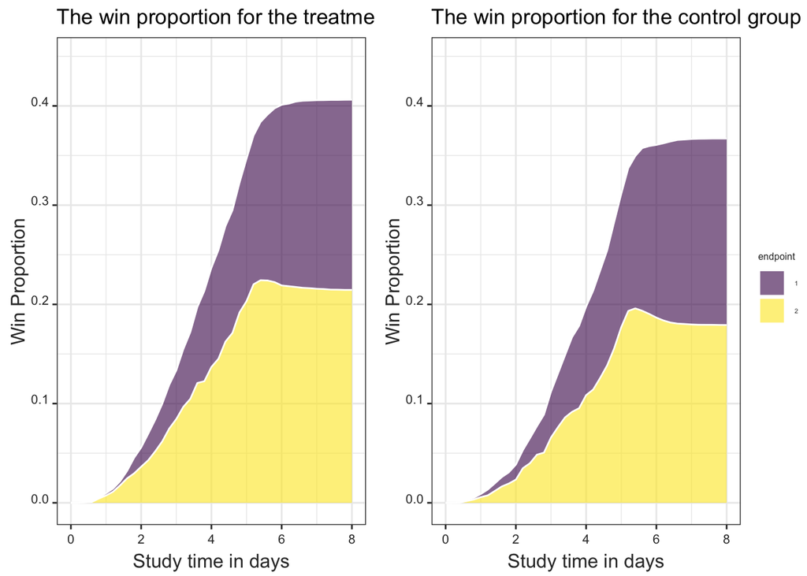

```
## $win_trt_t
##    time endpoint1 endpoint2
## 1   0.0  0.000000  0.000000
## 2   0.2  0.000000  0.000050
## 3   0.4  0.000000  0.000550
## 4   0.6  0.000500  0.000900
## 5   0.8  0.000600  0.004375
## 6   1.0  0.002275  0.007400
## 7   1.2  0.003075  0.011225
## 8   1.4  0.004075  0.017600
## 9   1.6  0.007450  0.024675
## 10  1.8  0.015700  0.029700
## 11  2.0  0.019325  0.036375
## 12  2.2  0.026625  0.042850
## 13  2.4  0.031850  0.051875
```

[output cut: 119 more lines]

```r
partition_t.plot(
  data,
  Ctime = seq(0,8,0.2),
  arm.name = c("A","B"),
  priority = c(1,2),
  tau = 0,
  plotTimeUnit = "days",
  trt_group = "both"
)
```

## Example 5: Plotting the Win Statistics for tte endpoints over the study time

This is a simulated example with two TTE endpoints.

```
## This analysis is unstratified.
```

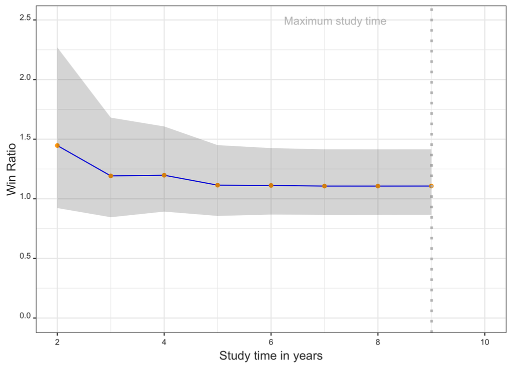

```
## $statistic
## [1] "WR"
##
## $values
##   time win_stat  lower_ci upper_ci
## 1    2 1.446753 0.9224056 2.269170
## 2    3 1.192007 0.8453348 1.680850
## 3    4 1.197623 0.8925942 1.606890
## 4    5 1.114288 0.8562580 1.450074
## 5    6 1.112066 0.8677469 1.425174
## 6    7 1.106709 0.8655303 1.415093
## 7    8 1.106647 0.8657029 1.414650
## 8    9 1.106994 0.8659895 1.415071
```

```r
stat_t.plot(
  data,
  arm.name = c("A","B"),
  priority = c(1,2),
  Ctime = seq(2,12,1),
  plotTimeUnit = "years",
  statistic = "WR",
  tau = 0,
  stratum.weight = "unstratified",
  plot_CI = TRUE
)
```

# George Institute Cumulative analysis

In the re-analysis of the ADVANCE trial and in other George Institute trials, we have produced cumulative analyses to examine the relative impact of the outcome hierarchy in the overall win ratio estimate. By cumulative analyses, for a given outcome hierarchy we mean examining the win ratio based only on the first component, then on the first two components, and so on until all components are used (i.e. using the full hierarchy). This entailed writing some functions that would perform the incremental analysis and created the notion of a data-package, comprising a dataset to send to WINS, plus the label, type, and min difference (tau) for each variable.

```r
library(dplyr)
library(purrr)

data_package <- list(
  # Example dataset provided by WINS package
  df = data_binary %>%
    mutate(
      # In our functions, arm column must contain T and C, so recode:
      arm = case_when(
        arm == "A" ~ "T",
        arm == "B" ~ "C",
        .default = NA
      )
    ),
  ep_type = c("binary", "binary", "binary"),
  tau = c(0, 0, 0),
  labels = c("Mortality", "+ Hospitalisation", "+ AE") # For example
)

# Cumulative analysis:
source("functions.R")
x <-
  run_cumulative_analysis(
    data_package = data_package,
    priority = c(1, 2, 3)
  )
```

```
## The outcome type for all the endpoints:  binary
## This analysis is unstratified.
## This analysis is unstratified.
## This analysis is unstratified.
```

## Example 6 - the decision tree

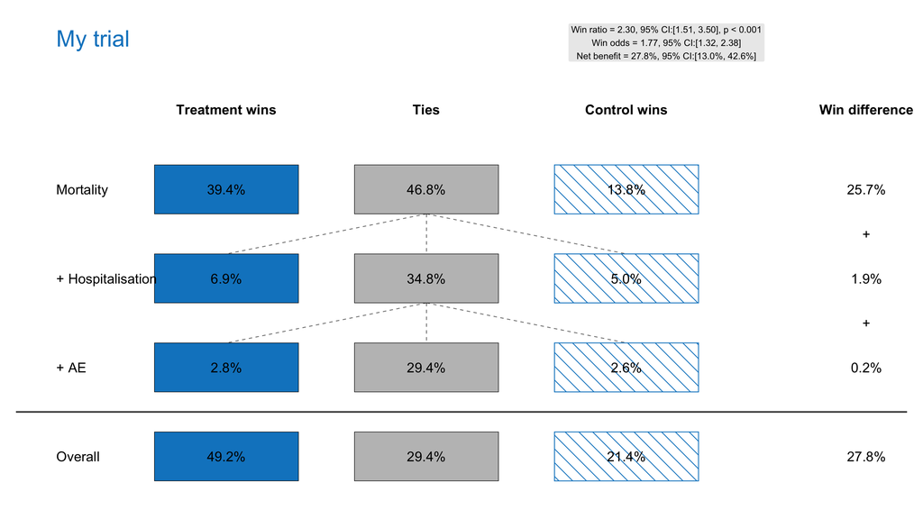

```r
wr_cumulative_flow_plot(x,
  plot_title = "My trial"
)
```

## Example 7 - cumulative plot

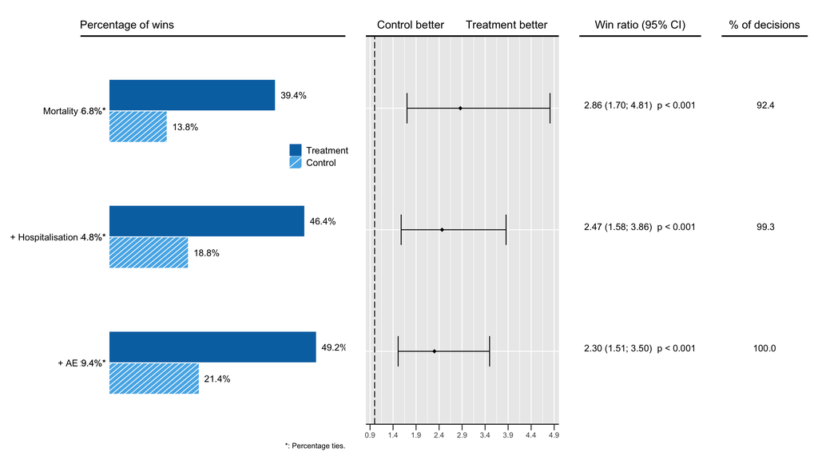

```r
wr_cumulative_panel_plot(x)
```